# lab4_luzanova_CLASSIFICATION

#“LOGISTIC REGRESSION” # Download the data

```r
set.seed(123)
f <- read.csv2('crime_index.csv', header = TRUE, encoding = 'UNICOD')
f <- f[,-c(1,2)]
head(f)
```

|  | cr_in | Population | gdp_p | unem | life_ex | dea | bir | emp | emp_s | emp_a | emp_i | edu_ex | mil_ex |
| --- | --- | --- | --- | --- | --- | --- | --- | --- | --- | --- | --- | --- | --- |
| 1 | 73.85 | 36296400 | 556.30 | 11.18 | 64.13 | 6.58 | 33.21 | 43.22 | 37.99 | 43.99 | 18.03 | 530307037 | 191407113 |
| 2 | 44.27 | 2873457 | 4531.02 | 13.75 | 78.33 | 7.71 | 11.93 | 48.22 | 42.44 | 38.20 | 19.35 | 431032412 | 144382689 |
| 3 | 49.63 | 41389198 | 4044.28 | 12.00 | 76.50 | 4.72 | 24.85 | 36.42 | 58.85 | 10.16 | 30.99 | 7361823737 | 10073364021 |
| 4 | 65.51 | 29816748 | 4095.81 | 7.12 | 60.38 | 8.43 | 41.28 | 72.05 | 41.07 | 50.56 | 8.37 | 4091869979 | 3062872914 |
| 5 | 62.63 | 44044811 | 14591.86 | 8.35 | 76.37 | 7.62 | 17.21 | 55.53 | 77.50 | 0.06 | 22.44 | 31276833378 | 5459643672 |
| 6 | 27.08 | 2944809 | 3914.50 | 17.70 | 74.80 | 9.86 | 14.30 | 45.80 | 51.95 | 31.34 | 16.71 | 273378561 | 443610413 |

#Розглянемо статистику та переведемо кількісну змінну до бінарних значень, де 1 будуть приймати значення більші за середнє значення, 0 - менші за середнє значення.

```r
library (psych)
f$cr_in<- ifelse(f$cr_in > mean(f$cr_in), 1, 0)
head (f)
```

|  | cr_in | Population | gdp_p | unem | life_ex | dea | bir | emp | emp_s | emp_a | emp_i | edu_ex | mil_ex |
| --- | --- | --- | --- | --- | --- | --- | --- | --- | --- | --- | --- | --- | --- |
| 1 | 1 | 36296400 | 556.30 | 11.18 | 64.13 | 6.58 | 33.21 | 43.22 | 37.99 | 43.99 | 18.03 | 530307037 | 191407113 |
| 2 | 0 | 2873457 | 4531.02 | 13.75 | 78.33 | 7.71 | 11.93 | 48.22 | 42.44 | 38.20 | 19.35 | 431032412 | 144382689 |
| 3 | 1 | 41389198 | 4044.28 | 12.00 | 76.50 | 4.72 | 24.85 | 36.42 | 58.85 | 10.16 | 30.99 | 7361823737 | 10073364021 |
| 4 | 1 | 29816748 | 4095.81 | 7.12 | 60.38 | 8.43 | 41.28 | 72.05 | 41.07 | 50.56 | 8.37 | 4091869979 | 3062872914 |
| 5 | 1 | 44044811 | 14591.86 | 8.35 | 76.37 | 7.62 | 17.21 | 55.53 | 77.50 | 0.06 | 22.44 | 31276833378 | 5459643672 |
| 6 | 0 | 2944809 | 3914.50 | 17.70 | 74.80 | 9.86 | 14.30 | 45.80 | 51.95 | 31.34 | 16.71 | 273378561 | 443610413 |

```r
describe(f)
```

|  | vars | n | mean | sd | median | trimmed | mad | min | max | range | skew | kurtosis | se |
| --- | --- | --- | --- | --- | --- | --- | --- | --- | --- | --- | --- | --- | --- |
| cr_in | 1 | 123 | 5.000000e-01 | 5.000000e-01 | 0.000000e+00 | 4.900000e-01 | 0.000000e+00 | 0.00 | 1.000000e+00 | 1.000000e+00 | 0.02 | -2.02 | 5.000000e-02 |
| Population | 2 | 123 | 5.579362e+07 | 1.771883e+08 | 1.075468e+07 | 2.292767e+07 | 1.306531e+07 | 343400.00 | 1.386395e+09 | 1.386052e+09 | 6.57 | 45.27 | 1.597653e+07 |
| gdp_p | 3 | 119 | 1.893301e+04 | 2.101956e+04 | 9.540630e+03 | 1.534589e+04 | 1.050704e+04 | 556.30 | 1.076271e+05 | 1.070709e+05 | 1.59 | 2.31 | 1.926860e+03 |
| unem | 4 | 123 | 7.460000e+00 | 5.200000e+00 | 5.760000e+00 | 6.740000e+00 | 3.850000e+00 | 0.14 | 2.707000e+01 | 2.693000e+01 | 1.31 | 1.51 | 4.700000e-01 |
| life_ex | 5 | 123 | 7.501000e+01 | 6.360000e+00 | 7.583000e+01 | 7.570000e+01 | 6.000000e+00 | 53.95 | 8.468000e+01 | 3.073000e+01 | -0.95 | 0.69 | 5.700000e-01 |
| dea | 6 | 123 | 7.730000e+00 | 2.950000e+00 | 7.110000e+00 | 7.570000e+00 | 2.950000e+00 | 1.17 | 1.550000e+01 | 1.433000e+01 | 0.48 | -0.05 | 2.700000e-01 |
| bir | 7 | 123 | 1.682000e+01 | 8.180000e+00 | 1.430000e+01 | 1.565000e+01 | 6.230000e+00 | 7.00 | 4.192000e+01 | 3.492000e+01 | 1.17 | 0.73 | 7.400000e-01 |
| emp | 8 | 123 | 5.695000e+01 | 1.119000e+01 | 5.802000e+01 | 5.661000e+01 | 9.270000e+00 | 33.41 | 8.671000e+01 | 5.330000e+01 | 0.20 | -0.18 | 1.010000e+00 |
| emp_s | 9 | 123 | 6.019000e+01 | 1.634000e+01 | 6.216000e+01 | 6.145000e+01 | 1.661000e+01 | 13.03 | 8.794000e+01 | 7.491000e+01 | -0.63 | -0.19 | 1.470000e+00 |
| emp_a | 10 | 123 | 1.818000e+01 | 1.884000e+01 | 1.070000e+01 | 1.504000e+01 | 1.259000e+01 | 0.06 | 8.330000e+01 | 8.324000e+01 | 1.32 | 1.13 | 1.700000e+00 |

[output cut: 3 more lines]

#Висновок: кількість спостережень – 123, кількість змінних – 13, всі кількісні. Є пропущені значеня та викиди

#Заповнимо пропущені значення - середніми значеннями

```r
f_fill <- f
f_fill$gdp_p <- ifelse(is.na(f$gdp_p),round(mean(f$gdp_p,na.rm = TRUE)),f$gdp_p)
f_fill$edu_ex <- ifelse(is.na(f$edu_ex),round(mean(f$edu_ex,na.rm = TRUE)),f$edu_ex)
f_fill$mil_ex <- ifelse(is.na(f$mil_ex),round(mean(f$mil_ex,na.rm = TRUE)),f$mil_ex)
f <- f_fill
head(f_fill)
```

|  | cr_in | Population | gdp_p | unem | life_ex | dea | bir | emp | emp_s | emp_a | emp_i | edu_ex | mil_ex |
| --- | --- | --- | --- | --- | --- | --- | --- | --- | --- | --- | --- | --- | --- |
| 1 | 1 | 36296400 | 556.30 | 11.18 | 64.13 | 6.58 | 33.21 | 43.22 | 37.99 | 43.99 | 18.03 | 530307037 | 191407113 |
| 2 | 0 | 2873457 | 4531.02 | 13.75 | 78.33 | 7.71 | 11.93 | 48.22 | 42.44 | 38.20 | 19.35 | 431032412 | 144382689 |
| 3 | 1 | 41389198 | 4044.28 | 12.00 | 76.50 | 4.72 | 24.85 | 36.42 | 58.85 | 10.16 | 30.99 | 7361823737 | 10073364021 |
| 4 | 1 | 29816748 | 4095.81 | 7.12 | 60.38 | 8.43 | 41.28 | 72.05 | 41.07 | 50.56 | 8.37 | 4091869979 | 3062872914 |
| 5 | 1 | 44044811 | 14591.86 | 8.35 | 76.37 | 7.62 | 17.21 | 55.53 | 77.50 | 0.06 | 22.44 | 31276833378 | 5459643672 |
| 6 | 0 | 2944809 | 3914.50 | 17.70 | 74.80 | 9.86 | 14.30 | 45.80 | 51.95 | 31.34 | 16.71 | 273378561 | 443610413 |

```r
describe(f)
```

|  | vars | n | mean | sd | median | trimmed | mad | min | max | range | skew | kurtosis | se |
| --- | --- | --- | --- | --- | --- | --- | --- | --- | --- | --- | --- | --- | --- |
| cr_in | 1 | 123 | 5.000000e-01 | 5.000000e-01 | 0.000000e+00 | 4.900000e-01 | 0.000000e+00 | 0.00 | 1.000000e+00 | 1.000000e+00 | 0.02 | -2.02 | 5.000000e-02 |
| Population | 2 | 123 | 5.579362e+07 | 1.771883e+08 | 1.075468e+07 | 2.292767e+07 | 1.306531e+07 | 343400.00 | 1.386395e+09 | 1.386052e+09 | 6.57 | 45.27 | 1.597653e+07 |
| gdp_p | 3 | 123 | 1.893301e+04 | 2.067211e+04 | 1.025423e+04 | 1.528928e+04 | 1.128785e+04 | 556.30 | 1.076271e+05 | 1.070709e+05 | 1.61 | 2.50 | 1.863940e+03 |
| unem | 4 | 123 | 7.460000e+00 | 5.200000e+00 | 5.760000e+00 | 6.740000e+00 | 3.850000e+00 | 0.14 | 2.707000e+01 | 2.693000e+01 | 1.31 | 1.51 | 4.700000e-01 |
| life_ex | 5 | 123 | 7.501000e+01 | 6.360000e+00 | 7.583000e+01 | 7.570000e+01 | 6.000000e+00 | 53.95 | 8.468000e+01 | 3.073000e+01 | -0.95 | 0.69 | 5.700000e-01 |
| dea | 6 | 123 | 7.730000e+00 | 2.950000e+00 | 7.110000e+00 | 7.570000e+00 | 2.950000e+00 | 1.17 | 1.550000e+01 | 1.433000e+01 | 0.48 | -0.05 | 2.700000e-01 |
| bir | 7 | 123 | 1.682000e+01 | 8.180000e+00 | 1.430000e+01 | 1.565000e+01 | 6.230000e+00 | 7.00 | 4.192000e+01 | 3.492000e+01 | 1.17 | 0.73 | 7.400000e-01 |
| emp | 8 | 123 | 5.695000e+01 | 1.119000e+01 | 5.802000e+01 | 5.661000e+01 | 9.270000e+00 | 33.41 | 8.671000e+01 | 5.330000e+01 | 0.20 | -0.18 | 1.010000e+00 |
| emp_s | 9 | 123 | 6.019000e+01 | 1.634000e+01 | 6.216000e+01 | 6.145000e+01 | 1.661000e+01 | 13.03 | 8.794000e+01 | 7.491000e+01 | -0.63 | -0.19 | 1.470000e+00 |
| emp_a | 10 | 123 | 1.818000e+01 | 1.884000e+01 | 1.070000e+01 | 1.504000e+01 | 1.259000e+01 | 0.06 | 8.330000e+01 | 8.324000e+01 | 1.32 | 1.13 | 1.700000e+00 |

[output cut: 3 more lines]

#Пропущені значення заповнено

#Замінемо значення, що приймаємо за викиди, граничними значеннями максимума та мінімума

```r
qn = quantile(f$Population, c(0.05, 0.95), na.rm = TRUE)
f = within(f, { Population= ifelse(Population < qn[1], qn[1], Population)
                  Population = ifelse(Population > qn[2], qn[2], Population)})
qn = quantile(f$gdp_p, c(0.05, 0.95), na.rm = TRUE)
f = within(f, { gdp_p= ifelse(gdp_p < qn[1], qn[1], gdp_p)
                  gdp_p = ifelse(gdp_p > qn[2], qn[2], gdp_p)})
qn = quantile(f$unem, c(0.05, 0.95), na.rm = TRUE)
f = within(f, { unem = ifelse(unem < qn[1], qn[1], unem)
                  unem = ifelse(unem > qn[2], qn[2], unem)})
qn = quantile(f$life_ex, c(0.05, 0.95), na.rm = TRUE)
f = within(f, { life_ex = ifelse(life_ex < qn[1], qn[1], life_ex)
                  life_ex = ifelse(life_ex > qn[2], qn[2], life_ex)})
qn = quantile(f$dea, c(0.05, 0.95), na.rm = TRUE)
f = within(f, { dea= ifelse(dea < qn[1], qn[1], dea)
                  dea = ifelse(dea > qn[2], qn[2], dea)})
qn = quantile(f$bir, c(0.05, 0.95), na.rm = TRUE)
f = within(f, { bir= ifelse(bir < qn[1], qn[1], bir)
                  bir = ifelse(bir > qn[2], qn[2], bir)})
qn = quantile(f$emp, c(0.05, 0.95), na.rm = TRUE)
f = within(f, { emp= ifelse(emp < qn[1], qn[1], emp)
                  emp = ifelse(emp> qn[2], qn[2], emp)})
qn = quantile(f$emp_s, c(0.05, 0.95), na.rm = TRUE)
f = within(f, { emp_s= ifelse(emp_s < qn[1], qn[1], emp_s)
                  emp_s = ifelse(emp_s > qn[2], qn[2], emp_s)})
qn = quantile(f$emp_a, c(0.05, 0.95), na.rm = TRUE)
f = within(f, { emp_a= ifelse(emp_a < qn[1], qn[1], emp_a)
                  emp_a = ifelse(emp_a > qn[2], qn[2], emp_a)})
qn = quantile(f$emp_i, c(0.05, 0.95), na.rm = TRUE)
f = within(f, { emp_i= ifelse(emp_i < qn[1], qn[1], emp_i)
                  emp_i = ifelse(emp_i > qn[2], qn[2], emp_i)})
qn = quantile(f$edu_ex, c(0.05, 0.95), na.rm = TRUE)
f = within(f, { edu_ex= ifelse(edu_ex < qn[1], qn[1], edu_ex)
                  edu_ex = ifelse(edu_ex > qn[2], qn[2], edu_ex)})
qn = quantile(f$mil_ex, c(0.05, 0.95), na.rm = TRUE)
f = within(f, { mil_ex= ifelse(mil_ex < qn[1], qn[1], mil_ex)
                  mil_ex = ifelse(mil_ex > qn[2], qn[2], mil_ex)})

describe(f)
```

|  | vars | n | mean | sd | median | trimmed | mad | min | max | range | skew | kurtosis | se |
| --- | --- | --- | --- | --- | --- | --- | --- | --- | --- | --- | --- | --- | --- |
| cr_in | 1 | 123 | 5.000000e-01 | 5.000000e-01 | 0.000000e+00 | 4.900000e-01 | 0.000000e+00 | 0.00 | 1.000000e+00 | 1.000000e+00 | 0.02 | -2.02 | 5.000000e-02 |
| Population | 2 | 123 | 3.460812e+07 | 4.958875e+07 | 1.075468e+07 | 2.292767e+07 | 1.306531e+07 | 647881.60 | 1.877530e+08 | 1.871052e+08 | 1.99 | 3.09 | 4.471267e+06 |
| gdp_p | 3 | 123 | 1.813714e+04 | 1.821617e+04 | 1.025423e+04 | 1.528928e+04 | 1.128785e+04 | 1393.23 | 6.081815e+04 | 5.942491e+04 | 1.12 | -0.02 | 1.642500e+03 |
| unem | 4 | 123 | 7.300000e+00 | 4.580000e+00 | 5.760000e+00 | 6.740000e+00 | 3.850000e+00 | 1.82 | 1.768000e+01 | 1.586000e+01 | 0.92 | -0.18 | 4.100000e-01 |
| life_ex | 5 | 123 | 7.518000e+01 | 5.750000e+00 | 7.583000e+01 | 7.570000e+01 | 6.000000e+00 | 63.06 | 8.266000e+01 | 1.959000e+01 | -0.63 | -0.44 | 5.200000e-01 |
| dea | 6 | 123 | 7.730000e+00 | 2.690000e+00 | 7.110000e+00 | 7.570000e+00 | 2.950000e+00 | 3.49 | 1.327000e+01 | 9.780000e+00 | 0.50 | -0.65 | 2.400000e-01 |
| bir | 7 | 123 | 1.658000e+01 | 7.440000e+00 | 1.430000e+01 | 1.565000e+01 | 6.230000e+00 | 8.30 | 3.317000e+01 | 2.487000e+01 | 0.89 | -0.30 | 6.700000e-01 |
| emp | 8 | 123 | 5.689000e+01 | 1.047000e+01 | 5.802000e+01 | 5.661000e+01 | 9.270000e+00 | 39.52 | 7.781000e+01 | 3.829000e+01 | 0.10 | -0.61 | 9.400000e-01 |
| emp_s | 9 | 123 | 6.039000e+01 | 1.530000e+01 | 6.216000e+01 | 6.145000e+01 | 1.661000e+01 | 28.61 | 8.161000e+01 | 5.299000e+01 | -0.47 | -0.78 | 1.380000e+00 |
| emp_a | 10 | 123 | 1.767000e+01 | 1.738000e+01 | 1.070000e+01 | 1.504000e+01 | 1.259000e+01 | 1.12 | 5.969000e+01 | 5.857000e+01 | 1.04 | 0.01 | 1.570000e+00 |

[output cut: 3 more lines]

```r
write.csv2(f, file = "crime_index_pre.csv")
```

#Позбавились викидів та пропущених значень.

# Features Scaling

```r
mPopulation <- mean(f$Population)
sPopulation <- sd(f$Population)
f$Population <- (f$Population-mPopulation)/sPopulation

mgdp_p <- mean(f$gdp_p)
sgdp_p <- sd(f$gdp_p)
f$gdp_p<- (f$gdp_p-mgdp_p)/sgdp_p

munem <- mean(f$unem)
sunem <- sd(f$unem)
f$unem <- (f$unem-munem)/sunem

mlife_ex <- mean(f$life_ex)
slife_ex <- sd(f$life_ex)
f$life_ex <- (f$life_ex-mlife_ex)/slife_ex

mdea <- mean(f$dea)
sdea <- sd(f$dea)
f$dea<- (f$dea-mdea)/sdea

mbir <- mean(f$bir)
sbir <- sd(f$bir)
f$bir <- (f$bir-mbir)/sbir

memp <- mean(f$emp)
semp <- sd(f$emp)
f$emp <- (f$emp-memp)/semp

memp_s <- mean(f$emp_s)
semp_s <- sd(f$emp_s)
f$emp_s<- (f$emp_s-memp_s)/semp_s

memp_a <- mean(f$emp_a)
semp_a <- sd(f$emp_a)
f$emp_a <- (f$emp_a-memp_a)/semp_a

memp_i <- mean(f$emp_i)
semp_i <- sd(f$emp_i)
f$emp_i <- (f$emp_i-memp_i)/semp_i

medu_ex <- mean(f$edu_ex)
sedu_ex <- sd(f$edu_ex)
f$edu_ex<- (f$edu_ex-medu_ex)/sedu_ex

mmil_ex <- mean(f$mil_ex)
smil_ex <- sd(f$mil_ex)
f$mil_ex <- (f$mil_ex-mmil_ex)/smil_ex

head (f)
```

|  | cr_in | Population | gdp_p | unem | life_ex | dea | bir | emp | emp_s | emp_a | emp_i | edu_ex | mil_ex |
| --- | --- | --- | --- | --- | --- | --- | --- | --- | --- | --- | --- | --- | --- |
| 1 | 1 | 0.03404554 | -0.9191786 | 0.8472187 | -1.92163256 | -0.428923107 | 2.23006043 | -1.3054994 | -1.4645832 | 1.5143179 | -0.5351602 | -0.6024304 | -0.6393203 |
| 2 | 0 | -0.63995695 | -0.7469257 | 1.4084049 | 0.54801921 | -0.008656897 | -0.62521158 | -0.8281562 | -1.1736896 | 1.1812142 | -0.3296526 | -0.6056667 | -0.6430138 |
| 3 | 1 | 0.13674621 | -0.7736459 | 1.0262742 | 0.22974718 | -1.120688727 | 1.11185648 | -1.6591152 | -0.1009786 | -0.4319510 | 1.4825507 | -0.3797282 | 0.1368544 |
| 4 | 1 | -0.09662224 | -0.7708171 | -0.0393244 | -2.10703037 | 0.259123343 | 2.23006043 | 1.4468612 | -1.2632456 | 1.8922956 | -2.0162161 | -0.4863262 | -0.4137821 |
| 5 | 1 | 0.19029893 | -0.1946230 | 0.2292589 | 0.20713769 | -0.042129427 | 0.08467382 | -0.1302805 | 1.1181597 | -0.9523177 | 0.1514220 | 0.3998826 | -0.2255286 |
| 6 | 0 | -0.63851808 | -0.7807704 | 2.2665612 | -0.06591535 | 0.790964652 | -0.30656984 | -1.0591903 | -0.5520271 | 0.7865525 | -0.7406678 | -0.6071068 | -0.6195111 |

#Висновок: моделі класифікації вимагають попереднього шкалювання кількісних змінних. Шкалювання виконано.

# Splitting the scaled dataset into the TRAIN set and TEST set

```r
set.seed(123)
library(caTools)
split = sample.split(f$cr_in, SplitRatio = 0.7)
f_train_c = subset(f, split == TRUE)
f_test_c = subset(f, split == FALSE)
```

#Висновок: підготований датасет розділено на навчальну та тестову вибірки. До тренувальної вибірки обрано 86 значень (70% від усіх спостережень), до тестової - 37 значення (30% від усіх спостережень)

# Fitting (Benchmark model)

```r
class_lr <- glm(cr_in ~ ., f_train_c, family = binomial)
summary(class_lr)
```

```
Call:
glm(formula = cr_in ~ ., family = binomial, data = f_train_c)

Deviance Residuals:
    Min       1Q   Median       3Q      Max
-3.4860  -0.5117  -0.0028   0.3855   2.2671

Coefficients:
            Estimate Std. Error z value Pr(>|z|)
(Intercept)   0.1984     0.4232   0.469  0.63926
Population    1.8712     0.8299   2.255  0.02415 *
gdp_p        -0.9677     0.7339  -1.319  0.18731
unem         -0.7932     0.6785  -1.169  0.24239
life_ex       0.4746     1.0555   0.450  0.65292
dea           0.9173     0.6522   1.406  0.15959
bir           3.6270     1.3661   2.655  0.00793 **
emp           0.1782     0.5699   0.313  0.75453
emp_s         3.3086     5.0076   0.661  0.50879
emp_a         1.3677     5.5564   0.246  0.80557
emp_i        -0.3131     2.0057  -0.156  0.87596
edu_ex       -1.4889     1.0051  -1.481  0.13853
mil_ex        0.2372     0.7067   0.336  0.73716
---
Signif. codes:  0 ‘***’ 0.001 ‘**’ 0.01 ‘*’ 0.05 ‘.’ 0.1 ‘ ’ 1

(Dispersion parameter for binomial family taken to be 1)

    Null deviance: 119.221  on 85  degrees of freedom
Residual deviance:  53.648  on 73  degrees of freedom
AIC: 79.648

Number of Fisher Scoring iterations: 7
```

```r
f_train_c = subset(f_train_c, select = -c(emp_i,emp,mil_ex,life_ex,gdp_p,unem,dea,emp_a  ))
f_test_c = subset(f_test_c, select = -c(emp_i,emp,mil_ex,life_ex,gdp_p,unem,dea,emp_a  ))
```

# Predicting

```r
p <- predict(class_opt, f_test_c[, c("edu_ex","Population" )], type = 'response')
y <- ifelse(p > 0.7, 1, 0)
```

#Висновок: розраховані ймовірності віднесення об’єктів до кожного з двох класів (вектор р), визначені класи об’єктів (вектор у).

## Confusion Matrix

```r
cm = table(f_test_c[, 'cr_in'], y > 0.7)
print(cm)
```

```
    FALSE TRUE
  0    17    2
  1    14    4
```

## ROC

```r
library(ROCR)
pref <- prediction(p, f_test_c$cr_in)
```

[output not shown]

# Visualising the Test set results

```r
library(ggplot2)
set = f_test_c[,c('edu_ex','Population','cr_in')]
X1 = seq(min(set['edu_ex']) - 1, max(set['edu_ex']) + 1, by = 0.01)
X2 = seq(min(set['Population']) - 1, max(set['Population']) + 1, by = 0.01)
grid_set = expand.grid(X1, X2)
colnames(grid_set) = c('edu_ex', 'Population')
prob_set = predict(class_opt, grid_set, type = 'response')
y_grid = ifelse(prob_set > 0.7, 1, 0)
plot(set[, -3],
     main = 'Logistic Regression',
     xlab = 'edu_ex', ylab = 'Population',
     xlim = range(X1), ylim = range(X2))
contour(X1, X2, matrix(as.numeric(y_grid), length(X1), length(X2)), add = TRUE)
```

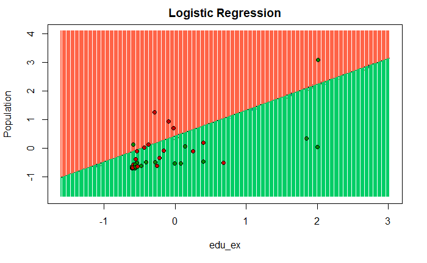

```r
points(grid_set, pch = '.', col = ifelse(y_grid == 1, 'tomato', 'springgreen3'))
points(set, pch = 21, bg = ifelse(set[, 3] == 1, 'red3', 'green4'))
```

#Висновок: на графіку червоним позначені “країни” з високим рівнем злочинності, зеленим – з низьким рівнем злочинності.Червоним виділена зона високої ймовірності високого значення рівня злочинності. Модель описує лінійний варіант розділяючої кривої.

#“K-Nearest Neighbors (K-NN)”

# Fitting & predicting

```r
library(class)
y = knn(train = f_train_c[,c('edu_ex','Population')],
        test = f_test_c[,c('edu_ex','Population')],
        cl = f_train_c[, 'cr_in'],
        k = 5,
        prob = TRUE)
```

#Висновок: і навчання, і прогнозування за моделлю k найближчих сусідів здійснюється однією функцією. У результаті отримуємо вектор класів об’єктів.

## Confusion Matrix

```r
cm = table(f_test_c[, 'cr_in'], y == '1')
print(cm)
```

```
    FALSE TRUE
  0    11    8
  1     5   13
```

#Висновок: точність моделі – (11+13) / 37 = 64.9 %, частка невірно класифікованих випадків – (5+8) / 37 = 35.1 %. Чутливість – 13 / (13+5) = 72.2 %, специфічність – 11 / (11+8) = 57,9 %, тобто модель більш чутлива до виявлення позитивних випадків. У цьому разі – “країн”, з високим рівнем злочинності

## Visualising the Test set results

```r
library(ggplot2)
set = f_test_c[,c('edu_ex','Population','cr_in')]
X1 = seq(min(set['edu_ex']) - 1, max(set['edu_ex']) + 1, by = 0.01)
X2 = seq(min(set['Population']) - 1, max(set['Population']) + 1, by = 0.01)
grid_set = expand.grid(X1, X2)
colnames(grid_set) = c('edu_ex', 'Population')
y_grid = knn(train = f_train_c[,c('edu_ex','Population')], test = grid_set, cl = f_train_c[, 'cr_in'], k = 5)
plot(set[, -3],
     main = 'KNN',
     xlab = 'edu_ex', ylab = 'Population',
     xlim = range(X1), ylim = range(X2))
contour(X1, X2, matrix(as.numeric(y_grid), length(X1), length(X2)), add = TRUE)
```

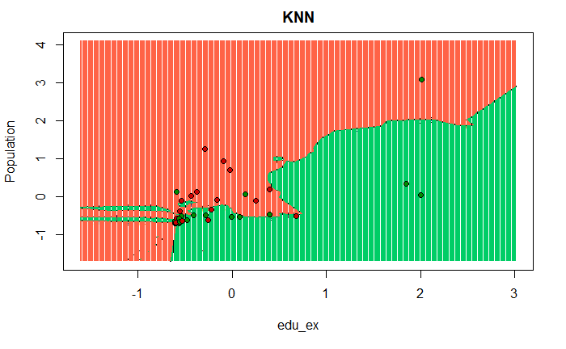

```r
points(grid_set, pch = '.', col = ifelse(y_grid == 1, 'tomato', 'springgreen3'))
points(set, pch = 21, bg = ifelse(set[, 3] == 1, 'red3', 'green4'))
```

#Висновок: на графіку червоним позначені “країни” з високим рівнем злочинності, зеленим – з низьким рівнем злочинності.Червоним виділена зона високої ймовірності високого значення рівня злочинності. Модель описує нелінійний варіант розділяючої кривої.

#“Support Vector Machine (SVM)”

# Fitting SVM model

```r
library(e1071)
class_svm_l = svm(cr_in ~ edu_ex + Population, data = f_train_c, kernel = 'linear')
summary(class_svm_l)
```

```
Call:
svm(formula = cr_in ~ edu_ex + Population, data = f_train_c, kernel = "linear")


Parameters:
   SVM-Type:  eps-regression
 SVM-Kernel:  linear
       cost:  1
      gamma:  0.5
    epsilon:  0.1


Number of Support Vectors:  82
```

# Predicting

```r
p <- predict(class_svm_l, f_test_c[, c('edu_ex','Population')])
y <- ifelse(p > 0.5, 1, 0)
```

#Висновок: визначено класи об’єктів (вектор у).

## Confusion Matrix

```r
cm = table(f_test_c[, 'cr_in'], y)
print(cm)
```

```
   y
     0  1
  0 18  1
  1 16  2
```

#Висновок: точність моделі - (18 + 2) / 37 = 54.1 %, частка невірно класифікованих випадків – (16 + 1) / 37 = 45,9 %. Чутливість моделі – 2 / (16 + 2) = 11.1 %, специфічність – 18 / (18 + 1) = 94,7 %, тобто модель більш чутлива до виявлення негативних випадків. У цьому разі – “країн”, з низьким рівнем злочинності

# Visualising the Test set results

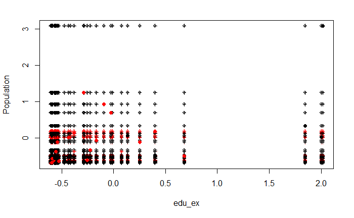

```r
xgrid = expand.grid(edu_ex = f_test_c$edu_ex, Population = f_test_c$Population)
ygrid = predict(class_svm_l, xgrid)
#Finally, you plot the points and color them according to the decision boundary. You can see that the decision boundary is linear. You can put the data points in the plot as well to see where they lie.
plot(xgrid, col = as.numeric(y_grid), pch = 10, cex = .9)
points(f_test_c[, c('edu_ex','Population')], col = as.factor(f_test_c$cr_in), pch = 19)
```

# Fitting RBF-kernel model

```r
library(e1071)
class_svm_r = svm(cr_in ~ edu_ex + Population, data = f_train_c, kernel = 'radial')
summary(class_svm_r)
```

```
Call:
svm(formula = cr_in ~ edu_ex + Population, data = f_train_c, kernel = "radial")


Parameters:
   SVM-Type:  eps-regression
 SVM-Kernel:  radial
       cost:  1
      gamma:  0.5
    epsilon:  0.1


Number of Support Vectors:  75
```

# Predicting

```r
p <- predict(class_svm_r, f_test_c[, c('edu_ex','Population')])
y <- ifelse(p > 0.5, 1, 0)
```

#Висновок: визначені класи об’єктів (вектор у).

## Confusion Matrix

```r
cm = table(f_test_c[, 'cr_in'], y)
print(cm)
```

```
   y
     0  1
  0 16  3
  1 10  8
```

# Visualising the Test set results

```r
library(ggplot2)
set = f_test_c[,c('edu_ex','Population','cr_in')]
X1 = seq(min(set['edu_ex']) - 1, max(set['edu_ex']) + 1, by = 0.01)
X2 = seq(min(set['Population']) - 1, max(set['Population']) + 1, by = 0.01)
grid_set = expand.grid(X1, X2)
colnames(grid_set) = c('edu_ex', 'Population')
p_grid = predict(class_svm_r, grid_set)
y_grid <- ifelse(p_grid > 0.5, 1, 0)
plot(set[, -3],
     main = 'SVM',
     xlab = 'edu_ex', ylab = 'Population',
     xlim = range(X1), ylim = range(X2))
contour(X1, X2, matrix(as.numeric(y_grid), length(X1), length(X2)), add = TRUE)
```

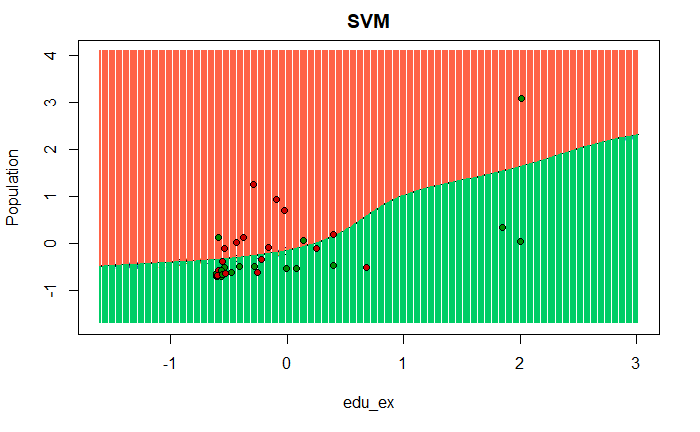

```r
points(grid_set, pch = '.', col = ifelse(y_grid == 1, 'tomato', 'springgreen3'))
points(set, pch = 21, bg = ifelse(set[, 3] == 1, 'red3', 'green4'))
```

#Висновок: на графіку червоним позначені “країни” з високим рівнем злочинності, зеленим – з низьким рівнем злочинності.Червоним виділена зона високої ймовірності високого значення рівня злочинності. Модель описує нелінійний варіант розділяючої кривої.

#“Naive Bayes” # Fitting

```r
library(e1071)
f_train_c$cr_in <- as.factor(f_train_c$cr_in)
f_test_c$cr_in <- as.factor(f_test_c$cr_in)
class_nb = naiveBayes(cr_in ~ edu_ex + Population, data = f_train_c)
```

#Висновок: для навчання моделі використано функцію naiveBayes.

# Predicting

```r
y <- predict(class_nb, f_test_c[, c('edu_ex','Population')])
```

#Висновок: визначено класи об’єктів (вектор у).

## Confusion Matrix

```r
cm = table(f_test_c[, 'cr_in'], y)
print(cm)
```

```
   y
     0  1
  0 17  2
  1 14  4
```

#Висновок: точність моделі - (17 + 4) / 37 = 56.8 %, частка невірно класифікованих випадків – (14 + 2) / 37 = 43,2 %. Чутливість моделі – 4 / (4 + 14) = 22.2 %, специфічність – 17 / (17 + 2) = 89.5 %, тобто модель більш чутлива до виявлення пнегативних випадків. У цьому разі – “країн”, з низьким рівнем злочинності

# Visualising the Test set results

```r
library(ggplot2)
set = f_test_c[,c('edu_ex','Population','cr_in')]
X1 = seq(min(set['edu_ex']) - 1, max(set['edu_ex']) + 1, by = 0.01)
X2 = seq(min(set['Population']) - 1, max(set['Population']) + 1, by = 0.01)
grid_set = expand.grid(X1, X2)
colnames(grid_set) = c('edu_ex', 'Population')
y_grid = predict(class_nb, grid_set)
plot(set[, -3],
     main = 'Naive Bayes',
     xlab = 'edu_ex', ylab = 'Population',
     xlim = range(X1), ylim = range(X2))
contour(X1, X2, matrix(as.numeric(y_grid), length(X1), length(X2)), add = TRUE)
```

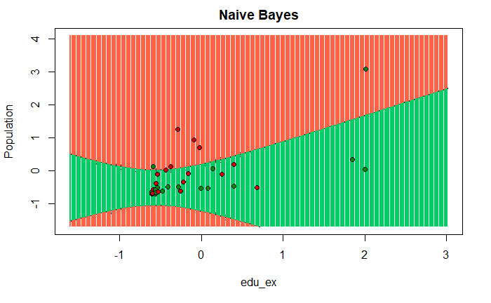

```r
points(grid_set, pch = '.', col = ifelse(y_grid == 1, 'tomato', 'springgreen3'))
points(set, pch = 21, bg = ifelse(set[, 3] == 1, 'red3', 'green4'))
```

#Висновок: на графіку червоним позначені “країни” з високим рівнем злочинності, зеленим – з низьким рівнем злочинності.Червоним виділена зона високої ймовірності високого значення рівня злочинності. Модель описує нелінійний варіант розділяючої кривої.

#“Classification Tree”

# Fitting

```r
library(rpart)
f_train_c$cr_in <- as.factor(f_train_c$cr_in)
f_test_c$cr_in <- as.factor(f_test_c$cr_in)
class_dt = rpart(cr_in ~ ., data = f_train_c)
```

## Predicting

```r
y <- predict(class_dt, f_test_c[-14], type = 'class')
```

#Висновок: визначені класи об’єктів (вектор у).

## Confusion Matrix

```r
cm = table(f_test_c[, 'cr_in'], y)
print(cm)
```

```
   y
     0  1
  0 14  5
  1  4 14
```

#Висновок: точність моделі – (14+14) / 37 = 75.7 %, частка невірно класифікованих випадків – (4+5) / 37 = 24.3 %. Чутливість – 14 / (14+4) = 77.8 %, специфічність – 14 / (14+5) = 73.7 %, тобто модель більш чутлива до виявлення позитивних випадків. У цьому разі – “країн”, з високим рівнем злочинносі

# Plotting the tree

[figure not shown]

```r
plot(class_dt)
text(class_dt)
```

#для аналізу необхідно перейти від шкальованих даних до реальних

# Fitting 2 factors

```r
class_ct = rpart(cr_in ~ edu_ex + Population, data = f_train_c)
```

## Predicting

```r
y <- predict(class_ct, f_test_c[, c('edu_ex', 'Population')], type = 'class')
```

#Висновок: визначено класи об’єктів (вектор у). Для цього використано параметр type = ‘class’.

## Confusion Matrix

```r
cm = table(f_test_c[, 'cr_in'], y)
print(cm)
```

```
   y
     0  1
  0 13  6
  1  7 11
```

#Висновок: точність моделі – (13+11) / 37 = 64.9 %, частка невірно класифікованих випадків – (7+6) / 37 = 35.1 %. Чутливість – 11 / (11+7) = 61.1 %, специфічність – 13/ (13+6) = 68.4 %, тобто модель більш чутлива до виявлення негативних випадків. У цьому разі – “країн”, з низьким рівнем злочинності

# Visualising the Test set results

```r
library(ggplot2)
set = f_test_c[,c('edu_ex','Population','cr_in')]
X1 = seq(min(set['edu_ex']) - 1, max(set['edu_ex']) + 1, by = 0.01)
X2 = seq(min(set['Population']) - 1, max(set['Population']) + 1, by = 0.01)
grid_set = expand.grid(X1, X2)
colnames(grid_set) = c('edu_ex', 'Population')
y_grid = predict(class_ct, grid_set, type = 'class')
plot(set[, -3],
     main = 'Classification Tree',
     xlab = 'edu_ex', ylab = 'Population',
     xlim = range(X1), ylim = range(X2))
contour(X1, X2, matrix(as.numeric(y_grid), length(X1), length(X2)), add = TRUE)
```

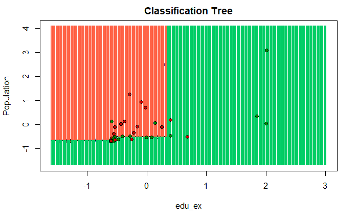

```r
points(grid_set, pch = '.', col = ifelse(y_grid == 1, 'tomato', 'springgreen3'))
points(set, pch = 21, bg = ifelse(set[, 3] == 1, 'red3', 'green4'))
```

#Висновок: на графіку червоним позначені “країни” з високим рівнем злочинності, зеленим – з низьким рівнем злочинності.Червоним виділена зона високої ймовірності високого значення рівня злочинності. Модель описує нелінійний варіант розділяючої кривої.

# Fitting Random Forest Classification to the Training set

```r
library(randomForest)
set.seed(123)
class_rf = randomForest(cr_in ~ edu_ex + Population, data = f_train_c, ntree = 10)
```

## Predicting

```r
y <- predict(class_rf, f_test_c[, c('edu_ex','Population')])
```

#Висновок: визначені класи об’єктів (вектор у).

## Confusion Matrix

```r
cm = table(f_test_c[, 'cr_in'], y)
print(cm)
```

```
   y
     0  1
  0 13  6
  1  5 13
```

# Visualising the Test set results

```r
set = f_test_c[,c('edu_ex','Population','cr_in')]
X1 = seq(min(set['edu_ex']) - 1, max(set['edu_ex']) + 1, by = 0.01)
X2 = seq(min(set['Population']) - 1, max(set['Population']) + 1, by = 0.01)
grid_set = expand.grid(X1, X2)
colnames(grid_set) = c('edu_ex', 'Population')
y_grid = predict(class_rf, grid_set)
plot(set[, -3],
     main = 'Random Forest',
     xlab = 'edu_ex', ylab = 'Population',
     xlim = range(X1), ylim = range(X2))
contour(X1, X2, matrix(as.numeric(y_grid), length(X1), length(X2)), add = TRUE)
```

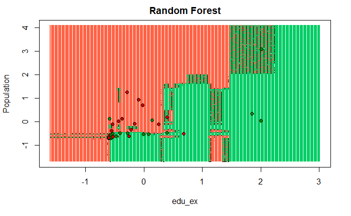

```r
points(grid_set, pch = '.', col = ifelse(y_grid == 1, 'tomato', 'springgreen3'))
points(set, pch = 21, bg = ifelse(set[, 3] == 1, 'red3', 'green4'))
```

#Висновок: на графіку червоним позначені “країни” з високим рівнем злочинності, зеленим – з низьким рівнем злочинності.Червоним виділена зона високої ймовірності високого значення рівня злочинності. Модель описує нелінійний варіант розділяючої кривої.

#“NEUORAL NETWORKS FOR CLASSIFICATION”

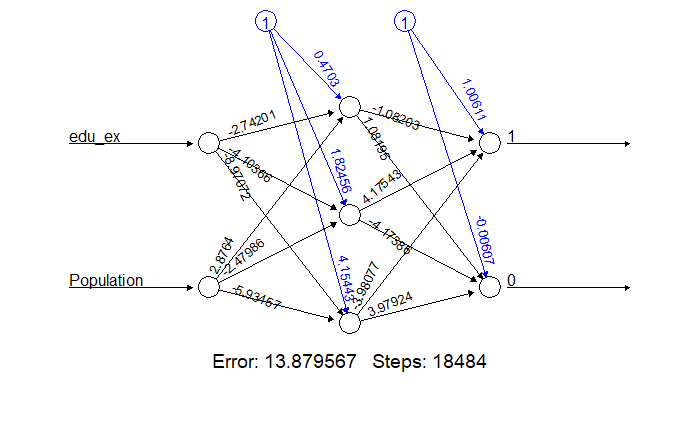

```r
library(neuralnet)
# fit neural network
nn = neuralnet(cr_in ~ edu_ex + Population, f_train_c, hidden = 3, linear.output = T)
# plot neural network
plot(nn)
```

#Висновок: на основі змінних edu_ex,Population побудовано двошарову нейронну мережу для прогнозування классу.

# Fitting the NN

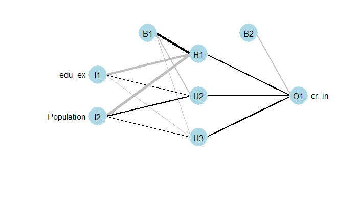

```r
library(nnet)
set.seed(11)
ff_cl <- nnet(data = f_train_c, cr_in ~ edu_ex + Population, size = 3, maxit = 1000)
library(graphics)
source(file = 'plot.nnet.R')
plot.nnet(ff_cl)
```

## Predicting

```r
#p_nn_cl <- predict(nn, f_test_c)
#p <- (p > 0.5)
#p <- as.factor(p_ff_cl)
p_ff_cl <- predict(ff_cl, f_test_c, type = "class")
p <- as.factor(p_ff_cl)
```

#### Висновок: визначені класи об’єктів (вектор p)

## Confusion Matrix

```r
cm = table(f_test_c[, 'cr_in'], p)
print(cm)
```

```
   p
     0  1
  0 16  3
  1 10  8
```

#Висновок: точність моделі – (16+8) / 37 = 64.9 %, частка невірно класифікованих випадків – (10+3) / 37 = 35.1 %. Чутливість – 8 / (10+8) = 44.4 %, специфічність – 16 / (16+3) = 84.2 %, тобто модель більш чутлива до виявлення негативних випадків. У цьому разі – “країн”, з низьким рівнем злочинності

#Отже, проведено класифікацію різними методами, серед яких: Logistic Regression, KNN, SVM, Naive Bayes, Classification Tree, Random Forest. За методом Classification Tree найменша кількість невірно віднесених значень - 9, при вибірці у 37 спостережень. Висновки по методу Classification Tree: тточність моделі – (14+14) / 37 = 75.7 %, частка невірно класифікованих випадків – (4+5) / 37 = 24.3 %. Чутливість – 14 / (14+4) = 77.8 %, специфічність – 14 / (14+5) = 73.7 %, тобто модель більш чутлива до виявлення позитивних випадків. У цьому разі – “країн”, з високим рівнем злочинносі